# Catalog v6.1: station terms scored on relative fit and absolute depth

D-B100 follow-up. Rule written 2026-11-26 13:09 PST (RESUME.md); scored 2026-11-26 14:54:18 PST. Branch reloc/v61-depth-test; data /wd1/mdenolle_data/reloc_v61/depth_test/.

**Winner by the pre-registered rule: `ssst16_coh`.** This is NLL-SSST stopped at 16 km (CharDist 9999 then 16 km, two Loc2ssst passes), followed by the coherence stage. It is the only arm that passes the relative-fit gate in all four clusters and both phases. Its depth score is D = 2.02 km, against 2.35 km for the v6.0 recipe `ssst4_coh`. The v6.0 recipe is out at the Gorda Depression: held-out MAD +23 ms [+8, +39] in P (against `static`) and +49 ms [+17, +79] in S (against `ssst16_coh`). The winner does not change if the Gorda Depression is left out, or if the gate is read as "interval excludes 0 and point difference above 5 %". These checks are not part of the rule.

**Depth by cluster, `ssst16_coh` / v6.0 recipe `ssst4_coh` / no terms `it0`.**

- Axial (1,191 tier A-B events; Waldhauser: 85 % within 1.6 km, 90 % within 2.0 km): within 2.0 km 89.1 / 87.7 / 91.2 %, within 1.6 km 56.4 / 54.0 / 66.4 %.
- Mount St Helens, ours minus Hirao (1,208 events): +1.26 / +1.15 / +1.53 km.
- Western Blanco, ours minus Lange (891 events): -0.40 / -0.36 / +0.93 km.
- Gorda Depression, ours minus Lange (497 events): +6.24 / +7.66 / +2.40 km.

**Implications for v6.1.**

- Whole margin: SSST 9999 then 16 km, then coherence (amends D-B096: stop at 16 km instead of 4 km; the Mendocino coherence skip of D-B098 is unchanged). The test supports one recipe for the margin: the same winner comes out with or without the Gorda Depression and under both readings of the gate. It gives no tested basis for a region-specific recipe. That would need its own pre-registered test, because the depth effect of the terms has opposite signs at Mount St Helens and the Gorda Depression.
- The change reduces the depth drift but does not remove it. On the v6.0 production tile t07_32, the pass with the same stop (it2) had 73.1 % of tier A-B Axial events within 2 km, against 66.3 % at it4 and 82.9 % without terms. v6.1 should therefore still be expected to miss the 85 % Axial target. This estimate uses v6.0's own passes, before coherence.
- The root cause remains. The terms are free to absorb the cluster's common shift (the JHD null space). At Axial, Puget and Blanco that shift appears mostly as a common S-P term, which is also partly a real Vp/Vs error of the model near the surface. The post-hoc arm `cm4` removes that term at every pass, and then 21 % of the Axial events end up on the seafloor floor. Neither "all to the terms" (SSST) nor "none to the terms" (`cm4`) matches the published depths in every cluster. A follow-up should: (1) fix the shallow Vp/Vs of the model where the terms need large common S corrections (Axial S -60 ms, Puget S -150 ms), so less has to go into the terms; and (2) test a tile-wise common-shift removal with every event weighted equally, with this protocol.

## 1. Why the SSST terms move depth (diagnosis on the v6.0 outputs)

Axial tile t07_32, the fixed set of the tile's Axial events with v6.0 tier A-B located in every pass (11,921 events). Depth below the seafloor = true depth + merged solid surface.

| pass | within 1.6 km (%) | within 2.0 km (%) | median below seafloor (km) | floor-limited (%) | median shift from it0 (km) | median rms (s) |
| --- | --- | --- | --- | --- | --- | --- |
| it0 no terms | 47.8 | 82.9 | 1.63 | 1.6 | +0.000 | 0.088 |
| it1 static (9999 km) | 37.4 | 76.6 | 1.71 | 4.2 | +0.074 | 0.064 |
| it2 SSST 16 km | 34.1 | 73.1 | 1.78 | 4.9 | +0.111 | 0.062 |
| it3 SSST 8 km | 31.4 | 69.2 | 1.81 | 4.9 | +0.147 | 0.062 |
| it4 SSST 4 km | 29.6 | 66.3 | 1.85 | 4.4 | +0.184 | 0.059 |

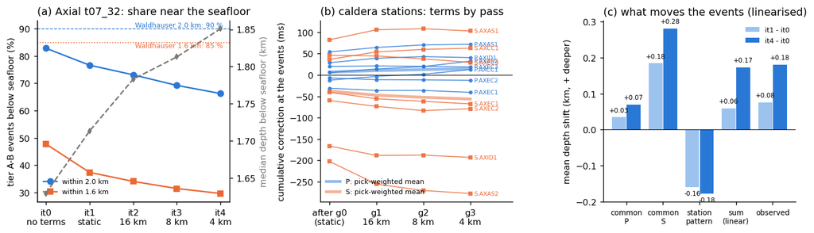

**Mechanism.** The caldera S terms are negative on average relative to the P terms: S-P common mode -40 ms after the static pass, -62 ms after the 4 km pass. The predicted S-P time gets shorter, so events move away from the seafloor array (deeper). For these events, depth and a common S term are nearly the same unknown. Adding a free common S term to an event's least-squares problem inflates its depth uncertainty by a median factor of 3.0, and the two parameters correlate at -0.94. This is the null space of joint hypocentre and station-correction inversion (JHD; Pujol 1988, BSSA 78): for a compact cluster, a common shift of all hypocentres plus a matching set of station corrections fits the arrivals equally well. Loc2ssst computes each term from the residuals at the current positions. Whatever S-P misfit the it0 positions leave (S arrives 0.03 s earlier than the model predicts at the caldera stations) goes into the terms. The relocation then lets the events relax along the null direction, which regenerates part of the same residual, and the next pass takes that up as well. The terms grow beyond the it0 mean residual (S.AXAS2 -0.17 s at it0, -0.20 s after the static pass, -0.28 s after the 4 km pass) and the cluster keeps drifting, by about the same amount per pass (+0.07, +0.04, +0.04, +0.04 km). The relative fit improves at every pass, while nothing in the data fixes the absolute depth.

**Other regions.** The busiest v6.0 tile of three other regions (tier A-C, medians over events, it4 - it0; table below) gives the same picture where the stations are close enough to constrain depth. At Puget (t29_40, land stations 10-20 km away) the events deepen by 0.50 km; the linearised shift is +0.52 km, of which +0.52 km comes from the common S part (S-P common term -153 ms). At Blanco (t11_23, OBS 20-40 km away) they deepen by 0.44 km (linearised +0.35 km, common S part +0.35 km). In both tiles depth trades with a common S term (median correlation -0.63 at Puget and +0.96 at Blanco; the depth uncertainty grows by a factor 1.4 at Puget and 4.2 at Blanco when the common S term is free). Gorda (t22_09, events 20-50 km from the nearest OBS) behaves differently. Most events move by more than 1 km between passes in both directions, the median shift changes sign from pass to pass (-0.11 km at it3, +0.13 km at it4), and the linearised shift comes from the station-to-station pattern (sediment-delayed S at the far OBS), not from a common S term. There the depth is poorly constrained by any recipe. The sign and size of the drift depend on the residual pattern that the it0 positions leave in each region. The cause is the same everywhere: the terms are free to take up the part of the residuals that a common shift of the cluster would explain.

**What this implies for the fix.** Stopping earlier does not remove the problem, because the static pass alone already moves the cluster (+0.07 km at Axial). The principled fix is to stop the terms from taking up that component: after every Loc2ssst pass, subtract from each station-phase the part of its correction that a common shift of the cluster (x, y, z, origin time) would produce. This is the minimum-norm constraint of JHD, applied per pass: a constant per station-phase, chosen so that the corrections no longer move the cluster to first order. Arm `nf4` of the test does this. No event is moved or clamped; relative positions remain free.

### The same decomposition in the busiest tile of other regions (tier A-C, medians over events)

| tile | events | dz it1 | it2 | it3 | it4 (km) | linearised it4 | common-P part | common-S part | station pattern | S-P common term (ms) | corr(z, common S) | sigma_z inflation | \|dz it4\| > 1 km (%) |
| --- | --- | --- | --- | --- | --- | --- | --- | --- | --- | --- | --- | --- | --- |
| Axial (t07_32) | 20,717 | +0.07 | +0.15 | +0.15 | +0.22 | +0.22 | +0.06 | +0.20 | -0.09 | -62 | -0.94 | 2.9 | 3 |
| Puget/Georgia (t29_40) | 1,435 | +0.29 | +0.44 | +0.51 | +0.50 | +0.52 | +0.23 | +0.52 | -0.26 | -153 | -0.63 | 1.4 | 45 |
| Gorda (t22_09) | 1,053 | -0.02 | -0.07 | -0.11 | +0.13 | -0.31 | +0.02 | +0.06 | -0.44 | +79 | 0.08 | 1.0 | 68 |
| Blanco (t11_23) | 6,293 | +0.15 | +0.29 | +0.33 | +0.44 | +0.35 | -0.09 | +0.35 | +0.02 | +63 | 0.96 | 4.2 | 54 |

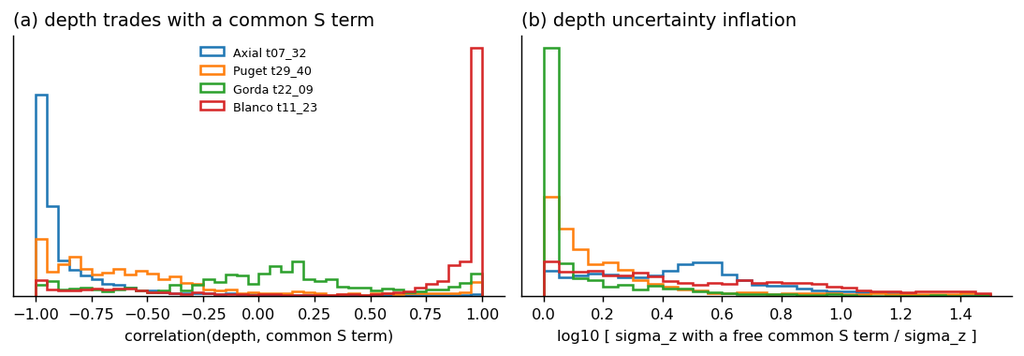

## 2. Pre-registered rule

Clusters (four, each with a literature reference): **axial** (D-B078 set, 1,200 events; Waldhauser et al. 2020: 85 % of events within 1.6 km and 90 % within 2.0 km of the seafloor), **msh** (D-B078 set, 1,436 events, 1,258 paired with Hirao et al. 2025), **blancow** (termtest set, western Blanco 2012, 1,200 events, 891 paired with Lange et al. 2026, absolute locations), **gordad** (new: the 503 catalog events paired with Lange et al. 2026 in the Gorda Depression segment, longitude -127.1 to -126.0; 497 of them tier A-C in v6.0, so it is included; it is dropped from the depth mean only if fewer than 100 paired tier A-C events are located in every arm of its full run).

Protocol: the v6.0 recipe of b4_v6_heldout.py (model v0.4.1 grids, fine 1 km or wide where the fine grid does not hold the box; box = set's v5.1 epicentres +- 30 km; NLLoc as v6.0; Loc2ssst LSPHSTAT/WeightFloor of b4_v6_ssst; coherence stage with partner rule R3; the Mendocino skip does not apply to these clusters). Runs: full (every station) and fold0-2 (the stations dealt into 3 folds with numpy default_rng(78 + set index), index 0 axial, 2 msh, 6 blancow, 9 gordad; each fold reruns everything without the picks and CC rows of its stations).

Arms (10): one SSST chain it0 -> g0 (CharDist 9999) -> it1 -> g1 (16) -> it2 -> g2 (8) -> it3 -> g3 (4) -> it4, plus a second chain nf (below), each with and without the coherence stage on its pass:

- `it0` no station terms; `it0_coh`
- `static` = it1 (one Loc2ssst static per station-phase, CharDist 9999 km); `static_coh`
- `ssst16` = it2 (SSST stopped at 16 km); `ssst16_coh`
- `ssst4` = it4 (SSST stopped at 4 km; `ssst4_coh` is the v6.0 recipe)
- `nf4` = the same schedule to 4 km, but after every Loc2ssst pass the part of the corrections that a common shift of the cluster could absorb is removed: per station-phase i a constant d_i = a_i . beta is subtracted from its correction (exact on the corrected time grids), with a_i = [dT/dx, dT/dy, dT/dz, 1] of station-phase i (base grid, arrival-weighted mean over the pass's events) and beta (4 numbers) chosen so that sum_e G_e' W_e (c_e - d) = 0 over the pass's located events e (G_e: their arrivals' partial derivatives at their positions, W_e: NLLoc arrival weights, c_e: the Loc2ssst increments at their positions). To first order the corrections then cannot move the cluster as a whole; relative positions are free. No event is moved or clamped. `nf4_coh`.

Scores: 1. Relative fit (held-out, leak-free): pooled over the 3 folds, per cluster and phase (P, S), MAD of the held-out CC differential-time residuals after removing each pair's median training residual (session -18's b5_cmp_common.fold_score, as D-B095/D-B096), on the rows located in every arm. 2. Absolute depth (full run): event-paired depth offset ours - published (km, positive = ours deeper), median and p10/p90, msh vs Hirao et al. 2025, blancow and gordad vs Lange et al. 2026 (absolute), on the paired events with v6.0 tier A-C located in every arm of the full run. Axial: share of the set's events with v6.0 tier A-B within 1.6 and 2.0 km below the seafloor (depth + merged surface), and as an offset in km: mean of [q85 - 1.6, q90 - 2.0], where q85, q90 are our 85th and 90th percentiles of depth below the seafloor (the shift that would put our distribution on Waldhauser's two quantiles). 3. Events above the solid surface (all runs).

Rule:

- (a) An arm with any event above the solid surface in any run is out.
- (b) Per cluster and phase, best = the arm with the lowest held-out MAD. An arm is out if, in any cluster and phase, the lower end of the 95 % paired-bootstrap interval of MAD(arm) - MAD(best) is above 5 % of MAD(best) (2,000 resamples of event pairs, the same resample for every arm).
- (c) Among the remaining arms, the one with the smallest D = mean over the literature clusters (axial, msh, blancow, gordad) of |depth offset| wins.
- (d) Arms with D within 0.05 km of the smallest D tie; a tie goes to the simplest recipe, in this order (simplest first): it0, it0_coh, static, static_coh, ssst16, ssst16_coh, ssst4, ssst4_coh, nf4, nf4_coh (fewer Loc2ssst passes first; without coherence before with; existing code before new code).
- An arm whose runs do not all finish is reported as incomplete and is not eligible.
- Reported, not part of the rule: p10/p90 of the offsets, the Axial shares, per-cluster offsets, Lange relative (double-difference) depths, floor-limited shares, held-out rms, relocated counts, the nf beta and d_i.

Caveat: the published depths have their own velocity models, station sets and datums (Lange's datum is not stated and is read as km below sea level; Hirao: km below sea level; Waldhauser: below the seafloor), so an offset of zero is not proof of a correct depth. The rule uses them as the reference anyway (PI, D-B100); the decision is about which recipe departs least from them, and the rule cannot see biases common to every arm (the model, v0.4.1).

## 3. Scores

Test clusters (each run: full = every station, fold0-2 = a third of the stations held out):

| set | region | events | picks | stations | accepted CC rows | CC pairs | time span |
| --- | --- | --- | --- | --- | --- | --- | --- |
| axial | Axial | 1,200 | 12,372 | 9 | 22,346 | 10,377 | 2014-11-09 to 2016-12-30 |
| msh | Cascades (Mount St Helens) | 1,436 | 30,881 | 109 | 50,389 | 12,627 | 2010-01-01 to 2016-12-30 |
| blancow | Blanco | 1,200 | 17,308 | 110 | 38,410 | 12,126 | 2012-10-02 to 2013-04-07 |
| gordad | Blanco (Gorda Depression) | 503 | 8,877 | 168 | 5,544 | 1,864 | 2012-09-24 to 2013-10-02 |

### Relative fit: held-out CC differential times (3 station folds pooled)

MAD of the pair-demeaned held-out residual (ms) on the rows located in every arm; difference to the best arm of the cluster and phase with its 95 % paired-bootstrap interval (2000 resamples of event pairs). Red: out by rule (b) (lower end above 5 % of the best).

**axial**: 9,523 P rows, 4,802 S rows

| arm | MAD P (ms) | P - best | MAD S (ms) | S - best |
| --- | --- | --- | --- | --- |
| it0 | 56.4 | +17.0 [+15.1, +18.3] | 76.2 | +26.6 [+23.2, +30.2] |
| it0_coh | 43.2 | +3.8 [+2.5, +5.2] | 49.6 | +0.0 [+0.0, +0.0] |
| static | 49.3 | +9.9 [+8.5, +11.3] | 74.6 | +25.0 [+21.7, +28.7] |
| static_coh | 40.3 | +0.9 [+0.0, +1.8] | 50.4 | +0.8 [-1.5, +3.0] |
| ssst16 | 49.7 | +10.3 [+8.9, +11.6] | 76.7 | +27.1 [+23.9, +30.7] |
| ssst16_coh | 39.4 | +0.0 [+0.0, +0.0] | 51.1 | +1.5 [-0.9, +3.7] |
| ssst4 | 50.3 | +10.9 [+9.5, +12.2] | 77.1 | +27.5 [+24.3, +30.8] |
| ssst4_coh | 40.8 | +1.4 [+0.5, +2.3] | 51.8 | +2.2 [-0.0, +4.7] |
| nf4 | 50.5 | +11.1 [+9.6, +12.4] | 77.8 | +28.2 [+25.0, +31.3] |
| nf4_coh | 40.2 | +0.8 [-0.2, +1.8] | 52.3 | +2.7 [+0.5, +5.2] |

**msh**: 28,727 P rows, 12,246 S rows

| arm | MAD P (ms) | P - best | MAD S (ms) | S - best |
| --- | --- | --- | --- | --- |
| it0 | 69.2 | +46.4 [+44.8, +48.3] | 83.9 | +63.9 [+60.5, +67.4] |
| it0_coh | 32.0 | +9.2 [+8.4, +10.2] | 26.3 | +6.3 [+5.4, +7.5] |
| static | 46.6 | +23.9 [+22.7, +25.1] | 50.9 | +30.9 [+28.9, +32.8] |
| static_coh | 24.3 | +1.6 [+1.1, +2.1] | 21.2 | +1.2 [+0.5, +1.8] |
| ssst16 | 44.4 | +21.6 [+20.4, +22.7] | 48.9 | +28.9 [+26.9, +30.7] |
| ssst16_coh | 23.0 | +0.3 [-0.1, +0.6] | 20.1 | +0.1 [-0.5, +0.6] |
| ssst4 | 44.1 | +21.3 [+20.3, +22.4] | 48.6 | +28.6 [+26.8, +30.6] |
| ssst4_coh | 22.8 | +0.0 [-0.3, +0.4] | 20.0 | +0.0 [+0.0, +0.0] |
| nf4 | 43.9 | +21.1 [+20.1, +22.3] | 48.0 | +28.0 [+26.1, +30.3] |
| nf4_coh | 22.8 | +0.0 [+0.0, +0.0] | 20.3 | +0.3 [-0.2, +0.8] |

**blancow**: 13,145 P rows, 16,954 S rows

| arm | MAD P (ms) | P - best | MAD S (ms) | S - best |
| --- | --- | --- | --- | --- |
| it0 | 233.1 | +140.4 [+132.1, +147.9] | 384.3 | +229.7 [+217.5, +242.4] |
| it0_coh | 233.1 | +140.4 [+132.2, +147.9] | 384.2 | +229.5 [+217.4, +242.3] |
| static | 112.1 | +19.4 [+15.9, +22.7] | 198.5 | +43.9 [+38.9, +49.8] |
| static_coh | 112.1 | +19.4 [+15.7, +22.5] | 198.7 | +44.1 [+39.1, +50.0] |
| ssst16 | 95.6 | +2.9 [+0.3, +5.2] | 162.2 | +7.6 [+4.2, +11.1] |
| ssst16_coh | 95.6 | +2.9 [+0.4, +5.1] | 162.2 | +7.5 [+4.2, +11.1] |
| ssst4 | 98.8 | +6.1 [+3.6, +8.4] | 154.7 | +0.0 [-0.3, +0.2] |
| ssst4_coh | 98.9 | +6.2 [+3.7, +8.5] | 154.6 | +0.0 [+0.0, +0.0] |
| nf4 | 93.0 | +0.3 [-0.4, +1.2] | 156.0 | +1.4 [-2.0, +5.5] |
| nf4_coh | 92.7 | +0.0 [+0.0, +0.0] | 155.8 | +1.2 [-2.2, +5.5] |

**gordad**: 2,095 P rows, 1,553 S rows

| arm | MAD P (ms) | P - best | MAD S (ms) | S - best |
| --- | --- | --- | --- | --- |
| it0 | 136.7 | +19.3 [+9.8, +31.9] | 447.0 | +182.5 [+132.3, +220.8] |
| it0_coh | 136.7 | +19.3 [+9.8, +32.0] | 447.0 | +182.5 [+132.3, +220.8] |
| static | 117.4 | +0.0 [+0.0, +0.0] | 275.9 | +11.4 [-18.9, +39.3] |
| static_coh | 117.5 | +0.2 [-1.0, +1.7] | 275.7 | +11.2 [-18.8, +39.2] |
| ssst16 | 124.6 | +7.3 [-1.6, +16.4] | 266.1 | +1.6 [-4.6, +6.8] |
| ssst16_coh | 124.5 | +7.2 [-2.0, +17.0] | 264.5 | +0.0 [+0.0, +0.0] |
| ssst4 | 142.2 | +24.8 [+11.3, +38.8] | 317.8 | +53.2 [+19.1, +82.3] |
| ssst4_coh | 140.6 | +23.3 [+8.4, +39.0] | 314.0 | +49.5 [+16.6, +79.2] |
| nf4 | 149.4 | +32.1 [+16.8, +49.3] | 335.8 | +71.3 [+30.4, +108.6] |
| nf4_coh | 147.6 | +30.3 [+14.9, +50.1] | 334.3 | +69.8 [+29.1, +106.5] |

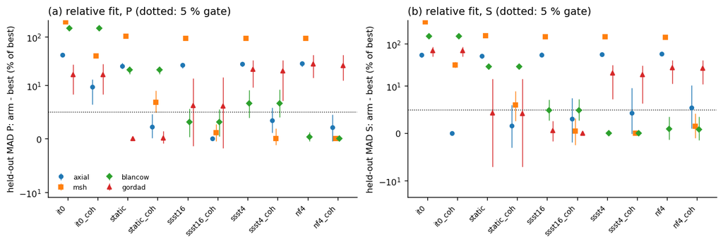

### Absolute depth (full runs) against the published catalogs

Ours - published (km, + = ours deeper): median [p10, p90], v6.0 tier A-C paired events located in every arm. Axial: v6.0 tier A-B events, shares within 1.6 / 2.0 km of the seafloor and the quantile offset mean(q85 - 1.6, q90 - 2.0).

**axial** vs Waldhauser et al. 2020 (seafloor quantiles), n = 1,191

| arm | within 1.6 km (%) | within 2.0 km (%) | q85 (km) | q90 (km) | median (km) | offset (km) |
| --- | --- | --- | --- | --- | --- | --- |
| it0 | 66.4 | 91.2 | 1.87 | 1.97 | 1.48 | +0.122 |
| it0_coh | 65.7 | 91.4 | 1.88 | 1.97 | 1.50 | +0.125 |
| static | 59.2 | 89.2 | 1.93 | 2.01 | 1.48 | +0.168 |
| static_coh | 58.5 | 89.0 | 1.95 | 2.02 | 1.50 | +0.183 |
| ssst16 | 56.8 | 88.7 | 1.93 | 2.01 | 1.49 | +0.170 |
| ssst16_coh | 56.4 | 89.1 | 1.95 | 2.02 | 1.51 | +0.185 |
| ssst4 | 54.9 | 87.6 | 1.95 | 2.07 | 1.52 | +0.207 |
| ssst4_coh | 54.0 | 87.7 | 1.96 | 2.07 | 1.57 | +0.217 |
| nf4 | 65.1 | 92.9 | 1.85 | 1.93 | 1.42 | +0.092 |
| nf4_coh | 63.3 | 92.9 | 1.85 | 1.94 | 1.47 | +0.094 |

**msh** vs Hirao et al. 2025, n = 1,208

| arm | offset median (km) | p10 | p90 | ours median (km) | published median (km) |
| --- | --- | --- | --- | --- | --- |
| it0 | +1.526 | +0.02 | +2.87 | 1.77 | 0.32 |
| it0_coh | +1.473 | +0.07 | +2.66 | 1.67 | 0.32 |
| static | +1.366 | +0.18 | +2.43 | 1.62 | 0.32 |
| static_coh | +1.360 | +0.17 | +2.37 | 1.59 | 0.32 |
| ssst16 | +1.260 | +0.09 | +2.30 | 1.53 | 0.32 |
| ssst16_coh | +1.263 | +0.09 | +2.28 | 1.52 | 0.32 |
| ssst4 | +1.134 | -0.01 | +2.25 | 1.39 | 0.32 |
| ssst4_coh | +1.151 | -0.02 | +2.22 | 1.38 | 0.32 |
| nf4 | +1.422 | +0.26 | +2.51 | 1.66 | 0.32 |
| nf4_coh | +1.438 | +0.25 | +2.52 | 1.67 | 0.32 |

**blancow** vs Lange et al. 2026 (absolute), n = 891

| arm | offset median (km) | p10 | p90 | ours median (km) | published median (km) | Lange relative: median [p10, p90] |
| --- | --- | --- | --- | --- | --- | --- |
| it0 | +0.932 | -3.66 | +15.95 | 8.05 | 7.50 | +0.88 [-3.6, +15.8] n=872 |
| it0_coh | +0.932 | -3.67 | +15.95 | 8.05 | 7.50 | +0.88 [-3.6, +15.8] n=872 |
| static | -0.140 | -2.28 | +11.86 | 7.50 | 7.50 | -0.20 [-2.4, +11.7] n=872 |
| static_coh | -0.156 | -2.25 | +11.86 | 7.50 | 7.50 | -0.20 [-2.4, +11.7] n=872 |
| ssst16 | -0.398 | -1.90 | +10.16 | 7.28 | 7.50 | -0.42 [-2.2, +9.7] n=872 |
| ssst16_coh | -0.398 | -1.88 | +10.16 | 7.28 | 7.50 | -0.42 [-2.2, +9.7] n=872 |
| ssst4 | -0.356 | -1.95 | +11.02 | 7.24 | 7.50 | -0.39 [-2.1, +10.8] n=872 |
| ssst4_coh | -0.356 | -1.91 | +11.02 | 7.24 | 7.50 | -0.38 [-2.1, +10.8] n=872 |
| nf4 | -2.378 | -3.81 | +6.47 | 4.96 | 7.50 | -2.44 [-4.1, +6.2] n=872 |
| nf4_coh | -2.361 | -3.80 | +8.38 | 4.96 | 7.50 | -2.40 [-4.0, +7.2] n=872 |

**gordad** vs Lange et al. 2026 (absolute), n = 497

| arm | offset median (km) | p10 | p90 | ours median (km) | published median (km) | Lange relative: median [p10, p90] |
| --- | --- | --- | --- | --- | --- | --- |
| it0 | +2.401 | -6.90 | +18.09 | 11.89 | 10.50 | +4.58 [-4.8, +19.4] n=452 |
| it0_coh | +2.401 | -6.90 | +18.09 | 11.89 | 10.50 | +4.58 [-4.8, +19.4] n=452 |
| static | +4.089 | -6.10 | +16.91 | 13.95 | 10.50 | +5.46 [-3.9, +18.3] n=452 |
| static_coh | +4.089 | -6.10 | +16.91 | 13.95 | 10.50 | +5.46 [-3.9, +18.3] n=452 |
| ssst16 | +6.241 | -5.32 | +17.66 | 16.38 | 10.50 | +7.50 [-3.3, +18.2] n=452 |
| ssst16_coh | +6.241 | -5.32 | +17.66 | 16.38 | 10.50 | +7.50 [-3.3, +18.3] n=452 |
| ssst4 | +7.593 | -4.65 | +18.27 | 17.77 | 10.50 | +8.92 [-2.9, +18.7] n=452 |
| ssst4_coh | +7.660 | -4.65 | +18.27 | 17.77 | 10.50 | +8.92 [-2.9, +19.0] n=452 |
| nf4 | +3.486 | -6.30 | +19.38 | 13.21 | 10.50 | +5.77 [-4.0, +20.3] n=452 |
| nf4_coh | +3.486 | -6.30 | +19.38 | 13.21 | 10.50 | +5.77 [-4.0, +20.3] n=452 |

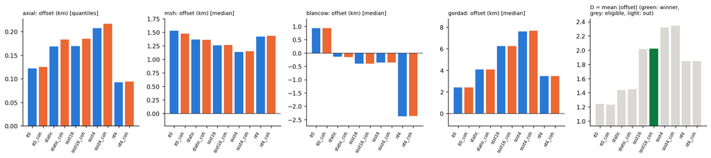

### Events above the solid surface; floor-limited share; coherence relocations (full runs)

| arm | above surface (all runs) | floor-limited % axial | floor-limited % blancow | floor-limited % gordad | floor-limited % msh | coherence-relocated axial | coherence-relocated blancow | coherence-relocated gordad | coherence-relocated msh |
| --- | --- | --- | --- | --- | --- | --- | --- | --- | --- |
| it0 | 0 | 1.0 | 6.6 | 16.5 | 0.4 | 0 | 0 | 0 | 0 |
| it0_coh | 0 | 0.7 | 6.6 | 16.5 | 0.3 | 1177 | 25 | 12 | 1235 |
| static | 0 | 5.2 | 0.9 | 2.4 | 0.1 | 0 | 0 | 0 | 0 |
| static_coh | 0 | 2.8 | 0.9 | 2.4 | 0.1 | 1176 | 62 | 22 | 1285 |
| ssst16 | 0 | 6.2 | 0.7 | 1.6 | 0.1 | 0 | 0 | 0 | 0 |
| ssst16_coh | 0 | 3.1 | 0.7 | 1.6 | 0.1 | 1175 | 68 | 33 | 1286 |
| ssst4 | 0 | 7.1 | 0.8 | 1.2 | 0.1 | 0 | 0 | 0 | 0 |
| ssst4_coh | 0 | 3.5 | 0.8 | 1.2 | 0.1 | 1176 | 41 | 58 | 1282 |
| nf4 | 0 | 9.2 | 1.9 | 2.6 | 0.1 | 0 | 0 | 0 | 0 |
| nf4_coh | 0 | 4.2 | 1.9 | 2.6 | 0.1 | 1175 | 147 | 67 | 1276 |

### nf4: the removed common-shift part (full runs)

beta = the common shift (dx, dy, dz km, dt0 s) whose travel-time signature a_i . beta was removed from the pass's increments (written as nf.json 'beta'; the key 'beta_names' of the runs mislabels the units as s/km); linearised mean depth shift of each event from the pass's increment, before and after the removal.

| set | pass | events | station-phases | beta_z (km) | beta_t0 (ms) | lin. dz before (km) | after (km) | negative nodes |
| --- | --- | --- | --- | --- | --- | --- | --- | --- |
| axial | g0 | 1,200 | 16 | -0.151 | +0.2 | +0.109 | -0.034 | 1 |
| axial | g1 | 1,200 | 16 | -0.009 | -2.8 | +0.015 | +0.008 | 1 |
| axial | g2 | 1,200 | 16 | -0.012 | +0.2 | +0.016 | +0.007 | 1 |
| axial | g3 | 1,200 | 16 | -0.015 | +1.2 | +0.015 | +0.004 | 1 |
| msh | g0 | 1,436 | 204 | +0.113 | +11.1 | -0.182 | -0.082 | 18 |
| msh | g1 | 1,436 | 204 | +0.093 | +6.6 | -0.122 | -0.038 | 24 |
| msh | g2 | 1,436 | 204 | +0.078 | +3.9 | -0.083 | -0.014 | 24 |
| msh | g3 | 1,436 | 204 | +0.060 | +3.1 | -0.053 | +0.000 | 24 |
| blancow | g0 | 1,199 | 143 | -1.766 | -115.8 | -0.953 | -1.712 | 0 |
| blancow | g1 | 1,200 | 143 | -0.064 | +1.7 | -0.334 | -0.377 | 0 |
| blancow | g2 | 1,200 | 143 | +0.034 | +8.8 | -0.093 | -0.067 | 0 |
| blancow | g3 | 1,200 | 143 | +0.036 | +7.0 | +0.014 | +0.040 | 0 |
| gordad | g0 | 503 | 250 | -2.394 | -47.1 | -0.025 | -0.704 | 0 |
| gordad | g1 | 503 | 250 | +0.207 | +29.6 | -0.165 | -0.080 | 0 |
| gordad | g2 | 503 | 250 | +0.248 | +24.1 | +0.078 | +0.162 | 4 |
| gordad | g3 | 503 | 250 | +0.040 | +9.3 | +0.088 | +0.095 | 2 |

## 4. Decision by the rule

[output not shown]

Literature clusters in D: axial, msh, blancow, gordad. Best arm per cluster and phase: axial P: ssst16_coh, axial S: it0_coh, msh P: nf4_coh, msh S: ssst4_coh, blancow P: nf4_coh, blancow S: ssst4_coh, gordad P: static, gordad S: ssst16_coh.

**Winner: ssst16_coh**

## 5. Post-hoc arm (not part of the decision)

Result: removing the common S-P term over-corrects in the other direction. At Axial, events move up against the seafloor: quantile offset -0.54 km, 96 % within 1.6 km, and 21.4 % floor-limited without coherence (10.3 % with), against 1.0 % with no terms. Western Blanco goes to -2.1 km against Lange, and the Gorda Depression to +8.0 km. Relative fit is worse than the best arm by more than the 5 % gate at western Blanco and the Gorda Depression, with and without coherence, and at Axial and Mount St Helens without coherence. So the S-P common term is not pure null space. It carries a real Vp/Vs error of the model near the seafloor: without it, a fifth of the Axial events would sit on the floor. The arrivals alone do not decide how much of that term belongs to the stations and how much to the hypocentres. SSST gives all of it to the stations, while `cm4` gives none of it. Neither matches all the published catalogs.

| arm | set | phase | MAD (ms) | registered best (ms) | arm - best | gate (b) |
| --- | --- | --- | --- | --- | --- | --- |
| cm4 | axial | P | 49.6 | ssst16_coh 39.4 | +10.2 [+8.6, +11.7] | out |
| cm4_coh | axial | P | 39.9 | ssst16_coh 39.4 | +0.5 [-0.6, +1.5] |  |
| cm4 | axial | S | 72.4 | it0_coh 49.6 | +22.8 [+19.3, +26.3] | out |
| cm4_coh | axial | S | 50.2 | it0_coh 49.6 | +0.5 [-1.8, +2.9] |  |
| cm4 | msh | P | 45.3 | nf4_coh 22.8 | +22.5 [+21.2, +23.7] | out |
| cm4_coh | msh | P | 23.4 | nf4_coh 22.8 | +0.6 [+0.3, +1.1] |  |
| cm4 | msh | S | 49.9 | ssst4_coh 20.0 | +29.9 [+27.8, +31.9] | out |
| cm4_coh | msh | S | 20.6 | ssst4_coh 20.0 | +0.6 [+0.2, +1.2] |  |
| cm4 | blancow | P | 104.4 | nf4_coh 92.7 | +11.7 [+9.3, +14.1] | out |
| cm4_coh | blancow | P | 104.6 | nf4_coh 92.7 | +11.9 [+9.6, +14.3] | out |
| cm4 | blancow | S | 169.0 | ssst4_coh 154.6 | +14.3 [+10.8, +18.0] | out |
| cm4_coh | blancow | S | 169.0 | ssst4_coh 154.6 | +14.4 [+10.9, +18.0] | out |
| cm4 | gordad | P | 154.4 | static 117.4 | +37.0 [+22.8, +54.1] | out |
| cm4_coh | gordad | P | 153.5 | static 117.4 | +36.1 [+21.0, +52.3] | out |
| cm4 | gordad | S | 314.3 | ssst16_coh 264.5 | +49.8 [+15.3, +83.7] | out |
| cm4_coh | gordad | S | 315.6 | ssst16_coh 264.5 | +51.1 [+16.8, +84.3] | out |

| arm | set | n | offset (km) |  |
| --- | --- | --- | --- | --- |
| cm4 | axial | 1,191 | -0.537 | within 1.6 / 2.0 km 96.1 / 99.1 % |
| cm4_coh | axial | 1,191 | -0.578 | within 1.6 / 2.0 km 96.7 / 99.3 % |
| cm4 | msh | 1,208 | +1.176 | p10 +0.05, p90 +2.27 |
| cm4_coh | msh | 1,208 | +1.172 | p10 +0.02, p90 +2.24 |
| cm4 | blancow | 891 | -2.141 | p10 -3.60, p90 +11.30 |
| cm4_coh | blancow | 891 | -2.135 | p10 -3.60, p90 +11.42 |
| cm4 | gordad | 497 | +8.002 | p10 -6.75, p90 +20.79 |
| cm4_coh | gordad | 497 | +8.102 | p10 -6.75, p90 +20.75 |

D (same four clusters): cm4 2.964 km, cm4_coh 2.997 km; gate (b) would exclude: {"cm4": ["axial P", "axial S", "msh P", "msh S", "blancow P", "blancow S", "gordad P", "gordad S"], "cm4_coh": ["blancow P", "blancow S", "gordad P", "gordad S"]}

## 6. Reproducibility

Code: branch `reloc/v61-depth-test` (commit `7b5fefaf`), workflow/10_tomography/: `b4_v61_depth_diag.py` (diagnosis; `--tile t07_32`, `--tile t29_40 --region Puget/Georgia --near-km 25`, `--tile t22_09 --region Gorda --near-km 40`, `--tile t11_23 --region Blanco --near-km 40`), `b4_v61_depth_sets.py` (gordad set), `b4_v61_depth_test.py run SET RUN` (16 chains, /wd1/mdenolle_data/reloc_v61/depth_test/run_chains.sh), `b4_v61_depth_test.py score --nboot 2000`, `b4_v61_depth_report.py`. Inputs: grids reloc_v6/time_v6_v0.4.1 and wide_time_v6_v0.4.1 (manifest dbe2f8a1), picks Cascadia_picks_catalog_v4.1tc.csv (md5 1b21ab1c), CC sets of D-B078 / termtest / cc_dt_all, literature pair tables tomo_v1/depth_literature/pairs/, catalog v6.0 tiers (md5 ae77ad3c). NonLinLoc 7.1.07 (ut-beg-texnet 3eb0c1e5) unchanged.